# Milo - simulations

Using Mike’s code from [here](https://www.dropbox.com/s/zr2znr0tftx59rv/graph_simulations.nb.html?dl=1)

## Testing with random sampling

### Simulate linear trajectory

Using [`dyntoy`](https://github.com/dynverse/dyntoy), I simulate linear trajectory (no branches) with 2000 cells and 5 main states (milestones).

```r
dataset <- generate_dataset(
  model = model_linear(num_milestones = 5),
  num_cells = 2000,
  num_features = 1000
)



sim_gex <- as.matrix(dataset$expression)
sim_branches <- dataset$prior_information$groups_id
```

Make a SingleCellExperiment object

```r
logcounts(sim_sce)
```

[output not shown]

[output cut: 113 more lines]

[output not shown]

Make Milo object

```r
sim_milo <- Milo(sim_sce)
sim_milo
```

```
class: Milo
dim: 1000 2000
metadata(0):
assays(1): expression
rownames(1000): G1 G2 ... G999 G1000
rowData names(0):
colnames(2000): C1 C10 ... C998 C999
colData names(1): group_id
reducedDimNames(1): PCA
altExpNames(0):
neighbourhoods dimensions(1): 0
neighbourhoodCounts dimensions(2): 1 1
neighbourDistances dimensions(2): 1 1
graph names(0):
```

### Build graph

```r
sim_milo <- buildGraph(sim_milo, k = 20, d = 30)
```

```
Constructing kNN graph with k:20
Retrieving distances from 20 nearest neighbours
```

### Make neighbourhoods

```r
sim_milo <- makeNeighbourhoods(sim_milo, prop = 0.1, k=20, d=30, refined = FALSE)
```

```
Checking valid object
```

```r
sim_milo
```

```
class: Milo
dim: 1000 2000
metadata(0):
assays(1): expression
rownames(1000): G1 G2 ... G999 G1000
rowData names(0):
colnames(2000): C1 C10 ... C998 C999
colData names(1): group_id
reducedDimNames(1): PCA
altExpNames(0):
neighbourhoods dimensions(1): 200
neighbourhoodCounts dimensions(2): 1 1
neighbourDistances dimensions(2): 2000 2000
graph names(1): graph
```

## Build KNN graph

set.seed(42) sim2.knn <- buildKNNGraph(x=sim2.pca$x[, c(1:30)], k=21, d=NA, transposed=TRUE)

## Run UMAP

stem.ta.umap <- umap(sim2.pca$x[, c(1:30)], n_components=2, n_neighbors=21, metric=‘euclidean’, init=‘random’, min_dist=0.1)

dyn.df <- data.frame(UMAP1=stem.ta.umap$layout[,1], UMAP2=stem.ta.umap$layout[,2], cell_id=rownames(sim2.gex)) dyn.df <- dyn.df %>% left_join(sim2.branches) dyn.df %>% ggplot(aes(UMAP1, UMAP2, color=group_id)) + geom_point()

### Simulate conditions

Assign different proportions of cells to group A and group B along the linear trajectory (with different proportion for cells assigned to each milestone).

n_groups <- length(unique(dyn.df$group_id)) p_vec <- seq(0.1,0.9, length.out = n_groups) a.cells <- c() for (i in 1:n_groups) { g <- sort(unique(dyn.df$group_id))[i] p <- p_vec[i] m.A <- sample(dyn.df$cell_id[dyn.df$group_id==g], size=floor(sum(dyn.df$group_id==g)*p)) a.cells <- c(a.cells, m.A) }

## Simulate replicates

dyn.df <- dyn.df %>% group_by(group_id) %>% dplyr::mutate(replicate=c(rep(1, floor(n()*0.3)), rep(2, floor(n()*0.3)), rep(3, n() - 2*(floor(n()*0.3)))) )

## Add sample name (condition + replicate)

ggplot(dyn.df, aes(UMAP1, UMAP2, color=condition)) + geom_point(size=0.5) + theme_clean() + facet_wrap(condition~.)

### Test for DA

`r`r quant_neighbourhood <- function(graph, meta, sample.column=‘Sample’, sample.vertices=0.25){ # Count conditions random.vertices <- sample(V(graph), size=floor(sample.vertices*length(V(graph)))) vertex.list <- sapply(1:length(random.vertices), FUN=function(X) neighbors(graph, v=random.vertices[X]))

count.matrix <- matrix(0L, ncol=length(unique(meta[, sample.column, drop=TRUE])), nrow=length(vertex.list)) colnames(count.matrix) <- unique(meta[, sample.column, drop=TRUE])

for(x in seq_along(1:length(vertex.list))){ v.x <- vertex.list[[x]] for(i in seq_along(1:length(unique(meta[, sample.column, drop=TRUE])))){ i.s <- unique(meta[, sample.column, drop=TRUE])[i] i.s.vertices <- intersect(v.x, meta[meta[, sample.column, drop=TRUE] == i.s, ]$Vertex)

```
  count.matrix[x, i] <- length(i.s.vertices)
}
```

} rownames(count.matrix) <- random.vertices return(list(count.matrix, vertex.list, random.vertices)) }

set.seed(400)

## Count A and B cells in neighboorhood of sampled cell

n.hood <- 0.1 # Fraction of sampled cells neigh.out <- quant_neighbourhood(graph=sim2.knn, meta=dyn.df, sample.column=‘sample’, sample.vertices=n.hood)

sim2.counts <- neigh.out[[1]] vertex.list <- neigh.out[[2]] random.vertices <- neigh.out[[3]]

## Test with edgeR

sim2.dge <- DGEList(sim2.counts[, rownames(sim2.model)], lib.size=log(colSums(sim2.counts))) sim2.dge <- estimateDisp(sim2.dge, sim2.model) sim2.fit <- glmQLFit(sim2.dge, sim2.model, robust=TRUE) sim2.contrast <- makeContrasts(ConditionA - ConditionB, levels=sim2.model) sim2.res <- glmQLFTest(sim2.fit, contrast=sim2.contrast) sim2.res <- as.data.frame(topTags(glmQLFTest(sim2.fit, coef=1), sort.by=‘none’, n=Inf)) sim2.res$Sig <- as.factor(as.numeric(sim2.res$PValue <= 0.05)) sim2.res$Neighbourhood <- as.numeric(rownames(sim2.res))

## Run spatialFDR adapted from cydar

`r`r fdr.df <- data.frame(Vertex=as.numeric(rownames(sim2.res)), p=sim2.res$PValue, adjp=sim2.spatialfdr, logFC=sim2.res$logFC, Sig=sim2.res$Sig)

dyn.df %>% left_join(fdr.df) %>% dplyr::arrange(p) %>% ggplot(aes(UMAP1, UMAP2, # color= - log10(adjp), # color= - log10(p), color = logFC )) + geom_point() + geom_point(data=. %>% dplyr::filter(!is.na(adjp))) + # geom_point(size=3, data=. %>% dplyr::filter(Vertex==197), color=) + scale_color_gradient2(midpoint = 0)

`r`r dyn.df %>% left_join(fdr.df) %>% dplyr::filter(!is.na(logFC)) %>% ggplot(aes(logFC, -log10(adjp), shape=Sig, color=group_id)) + geom_point() + facet_wrap(group_id~.)

## Refined sampling scheme

I adopt the refined sampling strategy applied in [Wishbone](https://www.nature.com/articles/nbt.3569#Sec12), and adapted from [here](https://www.nature.com/articles/nmeth.3545). Briefly, to avoid selecting outliers with random sampling, I first randomly select $n$ cells. For each sampled cell I then identify its k neares neighbors and compute the median profile of the neighbors (in this case the profile in reduced PC space). Then I replace each sampled cell by the cell closest to the median profile of its neighbors.

`r`r refine_vertex <- function(vertex.knn, v.ix, X_pca){ # vertex.knn: KNN graph for randomly sampled points (output of BiocNeighbors::findKNN) # v.ix: index of vertex to refine in vertex.knn

## Calculate median profile of KNNs of vertex v.med <- apply(X_pca[vertex.knn$index[v.ix,],], 2, median) ## Find the closest point to the median and sample refined.vertex <- BiocNeighbors::findKNN(rbind(v.med, X_pca), subset=1, k=1)[[]][1] - 1 ## -1 to remove the median return(refined.vertex) }

graph <- sim2.knn sample.vertices <- 0.1 X_pca <- sim2.pca$x[, c(1:30)]

random.vertices <- sample(V(graph), size=floor(sample.vertices*length(V(graph)))) vertex.knn <- BiocNeighbors::findKNN(X=X_pca, k=21, subset=as.vector(random.vertices)) refined.vertices <- V(graph)[sapply(1:nrow(vertex.knn$index), function(i) refine_vertex(vertex.knn, i, X_pca))]

vertex.list <- sapply(1:length(random.vertices), FUN=function(X) neighbors(graph, v=random.vertices[X])) vertex.list.refined <- sapply(1:length(refined.vertices), FUN=function(X) neighbors(graph, v=refined.vertices[X]))

`r`r bind_rows( data.frame(neighborhood_size = unlist(lapply(vertex.list, length)), sampling=), data.frame(neighborhood_size = unlist(lapply(vertex.list.refined, length)), sampling=) ) %>% ggplot(aes(neighborhood_size, fill=sampling)) + geom_histogram(bins=30) + facet_grid(sampling~.) + theme_grey(base_size=15)

`r`r dyn.df <- dyn.df %>% dplyr::mutate(random_sample=ifelse(Vertex %in% random.vertices, 1,0), refined_sample=ifelse(Vertex %in% refined.vertices, 1,0))

dyn.df %>% dplyr::arrange(random_sample) %>% ggplot(aes(UMAP1, UMAP2, color=random_sample)) + geom_point(size=0.5) + geom_point(data=. %>% dplyr::filter(random_sample==1), size=0.5) + scale_color_viridis_c(na.value=‘grey70’) +

dyn.df %>% dplyr::arrange(refined_sample) %>% ggplot(aes(UMAP1, UMAP2, color=refined_sample)) + geom_point(size=0.5) + geom_point(data=. %>% dplyr::filter(refined_sample==1), size=0.5) + scale_color_viridis_c(na.value=‘grey70’)

random_n <- c() refined_n <- c() for (x in seq(0.01,0.5, by = 0.05)) { for (i in 1:3){ random.vertices <- sample(V(graph), size=floor(x*length(V(graph)))) vertex.knn <- BiocNeighbors::findKNN(X=X_pca, k=21, subset=as.vector(random.vertices)) refined.vertices <- V(graph)[sapply(1:nrow(vertex.knn$index), function(i) refine_vertex(vertex.knn, i, X_pca))] l_ran <- length(random.vertices) l_ref <- length(unique(refined.vertices)) random_n <- c(random_n, l_ran) refined_n <- c(refined_n, l_ref) } }

data.frame(sample_proportion=lapply(seq(0.01,0.5, by = 0.05), function(x) rep(x, 3)) %>% purrr::reduce(c), random = random_n, refined = refined_n) %>% pivot_longer(cols = - sample_proportion, names_to = ‘sampling’, values_to = ) %>% ggplot(aes(sample_proportion, n, color=sampling)) + geom_point(size=1) + theme_clean(base_size = 16)

### Compare DA testing results

`r`r countCells <- function(graph, meta, vertex.list, random.vertices, sample.column=‘Sample’){ count.matrix <- matrix(0L, ncol=length(unique(meta[, sample.column, drop=TRUE])), nrow=length(vertex.list)) colnames(count.matrix) <- unique(meta[, sample.column, drop=TRUE])

for(x in seq_along(1:length(vertex.list))){ v.x <- vertex.list[[x]] for(i in seq_along(1:length(unique(meta[, sample.column, drop=TRUE])))){ i.s <- unique(meta[, sample.column, drop=TRUE])[i] i.s.vertices <- intersect(v.x, meta[meta[, sample.column, drop=TRUE] == i.s, ]$Vertex)

```
    count.matrix[x, i] <- length(i.s.vertices)
  }
}
rownames(count.matrix) <- random.vertices
return(count.matrix)
```

}

testQLF <- function(graph, sim2.counts, sim2.model, connectivity=‘edge’, pca=NULL){ sim2.dge <- DGEList(sim2.counts[, rownames(sim2.model)], lib.size=log(colSums(sim2.counts))) sim2.dge <- estimateDisp(sim2.dge, sim2.model) sim2.fit <- glmQLFit(sim2.dge, sim2.model, robust=TRUE) sim2.contrast <- makeContrasts(ConditionA - ConditionB, levels=sim2.model) sim2.res <- glmQLFTest(sim2.fit, contrast=sim2.contrast) sim2.res <- as.data.frame(topTags(glmQLFTest(sim2.fit, coef=1), sort.by=‘none’, n=Inf)) sim2.res$Sig <- as.factor(as.numeric(sim2.res$PValue <= 0.05)) sim2.res$Neighbourhood <- as.numeric(rownames(sim2.res))

sim2.spatialfdr <- graph_spatialFDR(neighborhoods=vertex.list, graph=graph, connectivity=connectivity, pvalues=sim2.res$PValue, pca = pca) return(list(res=sim2.res, spFDR=sim2.spatialfdr)) }

graph <- sim2.knn sample.vertices <- 0.1

random.vertices <- sample(V(graph), size=floor(sample.vertices*length(V(graph)))) vertex.knn <- BiocNeighbors::findKNN(X=X_pca, k=21, subset=as.vector(random.vertices)) refined.vertices <- V(graph)[sapply(1:nrow(vertex.knn$index), function(i) refine_vertex(vertex.knn, i, X_pca))]

vertex.list <- sapply(1:length(random.vertices), FUN=function(X) neighbors(graph, v=random.vertices[X])) vertex.list.refined <- sapply(1:length(refined.vertices), FUN=function(X) neighbors(graph, v=refined.vertices[X]))

count.matrix.random <- countCells(sim2.knn, dyn.df, vertex.list = vertex.list, random.vertices = random.vertices, sample.column = ) count.matrix.refined <- countCells(sim2.knn, dyn.df, vertex.list = vertex.list.refined, random.vertices = refined.vertices, sample.column = )

spFDR.random <- testQLF(sim2.knn, count.matrix.random, sim2.model) spFDR.refined <- testQLF(sim2.knn, count.matrix.refined, sim2.model)

`r`r fdr.df.random <- data.frame(Vertex=as.integer(rownames(spFDR.random$res)), p=spFDR.random$res$PValue, adjp=spFDR.random$spFDR, adjp_fdr=spFDR.random$res$FDR, logFC=spFDR.random$res$logFC, Sig=spFDR.random$res$Sig) fdr.df.refined <- data.frame(Vertex=as.integer(rownames(spFDR.refined$res)), p=spFDR.refined$res$PValue, adjp=spFDR.refined$spFDR, logFC=spFDR.refined$res$logFC, adjp_fdr=spFDR.refined$res$FDR, Sig=spFDR.refined$res$Sig)

dyn.df %>% left_join(fdr.df.random) %>% # dplyr::arrange(sampled) %>% ggplot(aes(UMAP1, UMAP2, # color= - log10(adjp), # color= - log10(p), color = logFC )) + geom_point(size=0.5) + geom_point(data=. %>% dplyr::filter(!is.na(adjp))) + theme_clean() + scale_color_gradient2(midpoint = 0, na.value =80) + ggtitle(sampling)

dyn.df %>% left_join(fdr.df.refined) %>% # dplyr::arrange(sampled) %>% ggplot(aes(UMAP1, UMAP2, # color= - log10(adjp), # color= - log10(p), color = logFC )) + geom_point(size=0.5) + geom_point(data=. %>% dplyr::filter(!is.na(adjp))) + theme_clean() + scale_color_gradient2(midpoint = 0, na.value =80) + ggtitle(sampling)

`r`r dyn.df %>% left_join(fdr.df.refined) %>% dplyr::filter(!is.na(logFC)) %>% ggplot(aes(logFC, -log10(adjp), shape=Sig, color=group_id)) + geom_point() + ggtitle(sampling) + dyn.df %>% left_join(fdr.df.random) %>% dplyr::filter(!is.na(logFC)) %>% ggplot(aes(logFC, -log10(adjp), shape=Sig, color=group_id)) + geom_point() + ggtitle(sampling)

`r`r dyn.df %>% left_join(fdr.df.refined) %>% dplyr::filter(!is.na(logFC)) %>% ggplot(aes(group_id, logFC, shape=Sig, color=group_id, size= -log10(adjp))) + geom_jitter() + ggtitle(sampling) + dyn.df %>% left_join(fdr.df.random) %>% dplyr::filter(!is.na(logFC)) %>% ggplot(aes(group_id, logFC, shape=Sig, color=group_id, size= -log10(adjp))) + geom_jitter() + ggtitle(sampling)

`r`r fdr.df.refined %>% ggplot(aes(-log10(p), -log10(adjp))) + geom_abline(linetype=2) + geom_point() + ggtitle(sampling) + fdr.df.random %>% ggplot(aes(-log10(p), -log10(adjp))) + geom_abline(linetype=2) + ggtitle(sampling) + geom_point()

## Use larger dataset

I expect the advantage of refining the sampling scheme will be more obvious with a larger dataset. Let’s try with 5000 cells and 10 milestones.

`r`r simulate_linear_traj <- function(num_cells, num_milestones, num_features=1000, k_param=21, seed=42, prob_start=0.1, prob_end=0.9){ set.seed(seed) ## Generate simulated dataset of trajectory dataset <- generate_dataset( model = model_linear(num_milestones = num_milestones), num_cells = num_cells, num_features = num_features ) sim2.gex <- as.matrix(dataset$expression) sim2.branches <- dataset$prior_information$groups_id

## Build graph sim2.pca <- prcomp_irlba(sim2.gex, n=50, scale.=TRUE, center=TRUE) X_pca = sim2.pca$x[, c(1:30)] sim2.knn <- buildKNNGraph(x=X_pca, k=k_param, d=NA, transposed=TRUE) ## Run UMAP stem.ta.umap <- umap(sim2.pca$x[, c(1:30)], n_components=2, n_neighbors=k_param, metric=‘euclidean’, init=‘random’, min_dist=0.1) dyn.df <- data.frame(UMAP1=stem.ta.umap$layout[,1], UMAP2=stem.ta.umap$layout[,2], cell_id=rownames(sim2.gex)) dyn.df <- dyn.df %>% left_join(sim2.branches)

## Simulate conditions n_groups <- length(unique(dyn.df$group_id)) p_vec <- seq(prob_start, prob_end, length.out = n_groups) a.cells <- c() for (i in 1:n_groups) { g <- paste0(\M\,i) p <- p_vec[i] m.A <- sample(dyn.df$cell_id[dyn.df$group_id==g], size=floor(sum(dyn.df$group_id==g)*p)) a.cells <- c(a.cells, m.A) }

dyn.df <- dyn.df %>% dplyr::mutate(condition = ifelse(cell_id %in% a.cells, , ‘B’))

## Simulate replicates dyn.df <- dyn.df %>% group_by(group_id) %>% dplyr::mutate(replicate=c(rep(1, floor(n()*0.3)), rep(2, floor(n()*0.3)), rep(3, n() - 2*(floor(n()*0.3)))) )

## Add sample name (condition + replicate) dyn.df$sample <- paste(dyn.df$condition, dyn.df$replicate, sep=\_\) ## Add vertex id (for counts) dyn.df$Vertex <- as.vector(V(sim2.knn))

return(list(graph=sim2.knn, X_pca=X_pca, meta.df=dyn.df, model=sim2.model))

}

data_5k_cells <- simulate_linear_traj(num_cells = 5000, num_milestones = 10)

```
tied distances detected in nearest-neighbor calculationJoining, by = \cell_id\
Column `cell_id` joining factor and character vector, coercing into character vector
```

`r`r data_5k_cells$meta.df %>% ggplot(aes(UMAP1, UMAP2, color=group_id)) + geom_point(size=0.2) + geom_text(data = . %>% group_by(group_id) %>% summarise(UMAP1=first(UMAP1), UMAP2=first(UMAP2)), aes(label=group_id), color=)

data_5k_cells$meta.df %>% ggplot(aes(UMAP1, UMAP2, color=condition)) + geom_point(size=0.2)

### Compare DA testing results

`r`r graph <- data_5k_cells$graph sample.vertices <- 0.1 meta.df <- data_5k_cells$meta.df model <- data_5k_cells$model X_pca <- data_5k_cells$X_pca

random.vertices <- sample(V(graph), size=floor(sample.vertices*length(V(graph)))) vertex.knn <- BiocNeighbors::findKNN(X=X_pca, k=21, subset=as.vector(random.vertices)) refined.vertices <- V(graph)[sapply(1:nrow(vertex.knn$index), function(i) refine_vertex(vertex.knn, i, X_pca))]

vertex.list <- sapply(1:length(random.vertices), FUN=function(X) neighbors(graph, v=random.vertices[X])) vertex.list.refined <- sapply(1:length(refined.vertices), FUN=function(X) neighbors(graph, v=refined.vertices[X]))

count.matrix.random <- countCells(graph, meta.df, vertex.list = vertex.list, random.vertices = random.vertices, sample.column = ) count.matrix.refined <- countCells(graph, meta.df, vertex.list = vertex.list.refined, random.vertices = refined.vertices, sample.column = )

spFDR.random <- testQLF(graph, count.matrix.random, model) spFDR.refined <- testQLF(graph, count.matrix.refined, model)

`r`r fdr.df.random <- data.frame(Vertex=as.integer(rownames(spFDR.random$res)), p=spFDR.random$res$PValue, adjp=spFDR.random$spFDR, adjp_fdr=spFDR.random$res$FDR, logFC=spFDR.random$res$logFC, Sig=spFDR.random$res$Sig) fdr.df.refined <- data.frame(Vertex=as.integer(rownames(spFDR.refined$res)), p=spFDR.refined$res$PValue, adjp=spFDR.refined$spFDR, logFC=spFDR.refined$res$logFC, adjp_fdr=spFDR.refined$res$FDR, Sig=spFDR.refined$res$Sig)

meta.df %>% left_join(fdr.df.random) %>% # dplyr::arrange(sampled) %>% ggplot(aes(UMAP1, UMAP2, # color= - log10(adjp), # color= - log10(p), color = logFC )) + geom_point(size=0.5) + geom_point(data=. %>% dplyr::filter(!is.na(adjp))) + theme_clean() + scale_color_gradient2(midpoint = 0, high = , low=,na.value =80) + ggtitle(sampling)

meta.df %>% left_join(fdr.df.refined) %>% # dplyr::arrange(sampled) %>% ggplot(aes(UMAP1, UMAP2, # color= - log10(adjp), # color= - log10(p), color = logFC )) + geom_point(size=0.5) + geom_point(data=. %>% dplyr::filter(!is.na(adjp))) + theme_clean() + scale_color_gradient2(midpoint = 0, high = , low=,na.value =80) + ggtitle(sampling)

`r`r meta.df %>% left_join(fdr.df.refined) %>% dplyr::filter(!is.na(logFC)) %>% ggplot(aes(logFC, -log10(adjp), shape=Sig, color=group_id)) + geom_point() + ggtitle(sampling) + meta.df %>% left_join(fdr.df.random) %>% dplyr::filter(!is.na(logFC)) %>% ggplot(aes(logFC, -log10(adjp), shape=Sig, color=group_id)) + geom_point() + ggtitle(sampling)

`r`r num_milestones=10

meta.df %>% ungroup() %>% left_join(fdr.df.refined) %>% dplyr::mutate(group_id = factor(group_id, levels=paste0(‘M’, 1:num_milestones))) %>% dplyr::filter(!is.na(logFC)) %>% ggplot(aes(group_id, logFC, shape=Sig, color=group_id, size= -log10(adjp))) + geom_jitter() + ggtitle(sampling) + meta.df %>% ungroup() %>% left_join(fdr.df.random) %>% dplyr::mutate(group_id = factor(group_id, levels=paste0(‘M’, 1:num_milestones))) %>% dplyr::filter(!is.na(logFC)) %>% ggplot(aes(group_id, logFC, shape=Sig, color=group_id, size= -log10(adjp))) + geom_jitter() + ggtitle(sampling)

What is the relationship between neighborhood size and testing outcomes?

`r`r fdr.df.random$neigh_size <- sapply(vertex.list, function(x) length(x)) fdr.df.refined$neigh_size <- sapply(vertex.list.refined, function(x) length(x))

fdr.df.random %>% ggplot(aes(neigh_size, -log10(adjp), color=Sig, # size= -log10(adjp)) )) + geom_point() + ggtitle(sampling) + fdr.df.refined %>% ggplot(aes(neigh_size, -log10(adjp), color=Sig, # size= -log10(adjp) )) + geom_point() + ggtitle(sampling)

## Robustness of test outcomes

I want to check whether using refined sampling allows to have more logFC even with different sampling

`r`r spFDR.random$res intersect(random.vertices, refined.vertices)

`r`r run_milo_sampling <- function(graph, meta.df, model, X_pca, seed=42, sample.vertices=0.1){ set.seed(seed) random.vertices <- sample(V(graph), size=floor(sample.vertices*length(V(graph)))) vertex.knn <- BiocNeighbors::findKNN(X=X_pca, k=21, subset=as.vector(random.vertices)) refined.vertices <- V(graph)[sapply(1:nrow(vertex.knn$index), function(i) refine_vertex(vertex.knn, i, X_pca))]

vertex.list <- sapply(1:length(random.vertices), FUN=function(X) neighbors(graph, v=random.vertices[X])) vertex.list.refined <- sapply(1:length(refined.vertices), FUN=function(X) neighbors(graph, v=refined.vertices[X]))

count.matrix.random <- countCells(sim2.knn, meta.df, vertex.list = vertex.list, random.vertices = random.vertices, sample.column = ) count.matrix.refined <- countCells(sim2.knn, meta.df, vertex.list = vertex.list.refined, random.vertices = refined.vertices, sample.column = )

spFDR.random <- testQLF(graph, count.matrix.random, model) spFDR.refined <- testQLF(graph, count.matrix.refined, model)

fdr.df.random <- data.frame(Vertex=as.integer(rownames(spFDR.random$res)), p=spFDR.random$res$PValue, adjp=spFDR.random$spFDR, adjp_fdr=spFDR.random$res$FDR, logFC=spFDR.random$res$logFC, Sig=spFDR.random$res$Sig) fdr.df.refined <- data.frame(Vertex=as.integer(rownames(spFDR.refined$res)), p=spFDR.refined$res$PValue, adjp=spFDR.refined$spFDR, logFC=spFDR.refined$res$logFC, adjp_fdr=spFDR.refined$res$FDR, Sig=spFDR.refined$res$Sig)

return(list(random=fdr.df.random, refined=fdr.df.refined)) }

sample_perc5 <- map(2020:2025, ~ run_milo_sampling(data_5k_cells$graph, data_5k_cells$meta.df, data_5k_cells$model, data_5k_cells$X_pca, seed=.x, sample.vertices = 0.05)) sample_perc10 <- map(2020:2025, ~ run_milo_sampling(data_5k_cells$graph, data_5k_cells$meta.df, data_5k_cells$model, data_5k_cells$X_pca, seed=.x, sample.vertices = 0.1)) sample_perc15 <- map(2020:2025, ~ run_milo_sampling(data_5k_cells$graph, data_5k_cells$meta.df, data_5k_cells$model, data_5k_cells$X_pca, seed=.x, sample.vertices = 0.15)) sample_perc20 <- map(2020:2025, ~ run_milo_sampling(data_5k_cells$graph, data_5k_cells$meta.df, data_5k_cells$model, data_5k_cells$X_pca, seed=.x, sample.vertices = 0.2))

make_test_df <- function(sample_df){ sample_df %>% imap( ~ bind_rows(.x[[]] %>% dplyr::mutate(sampling=), .x[[]] %>% dplyr::mutate(sampling=)) %>% dplyr::mutate(s=.y)) %>% purrr::reduce(bind_rows) %>% left_join(data_5k_cells$meta.df) %>% dplyr::mutate(group_id = factor(group_id, levels=paste0(‘M’, 1:num_milestones))) %>% group_by(sampling, s, group_id) %>% summarise(mean_logFC=mean(logFC)) }

map(list(perc5=sample_perc5, perc10=sample_perc10, perc15=sample_perc15, perc20=sample_perc20), ~ make_test_df(.x)) %>% imap( ~ dplyr::mutate(.x, perc=.y)) %>% purrr::reduce(bind_rows) %>% ggplot(aes(group_id, mean_logFC, color=perc)) + # geom_pointrange(stat = , # fun.min = min, # fun.max = max, # fun = mean) + geom_boxplot(varwidth = TRUE) + facet_grid(.~sampling) + scale_fill_gradient2()

## Compositional effect

Do I get high/low FC where unexpected just because things are changing elsewhere?

`r`r data_2k_cells <- simulate_linear_traj(num_cells = 2000, num_milestones = 10, prob_start = 0.5, prob_end=0.95)

`r`r ggplot(data_2k_cells$meta.df, aes(UMAP1, UMAP2, color=condition)) + geom_point(size=0.2) + theme_clean()

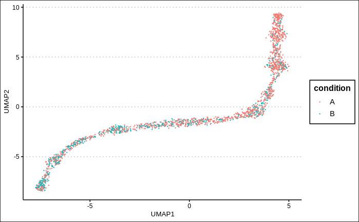

`r`r ggplot(data_2k_cells$meta.df, aes(UMAP1, UMAP2, color=group_id)) + geom_point(size=0.2) + theme_clean() + geom_text(data = . %>% group_by(group_id) %>% summarise(UMAP1=first(UMAP1), UMAP2=first(UMAP2)), aes(label=group_id), color=)

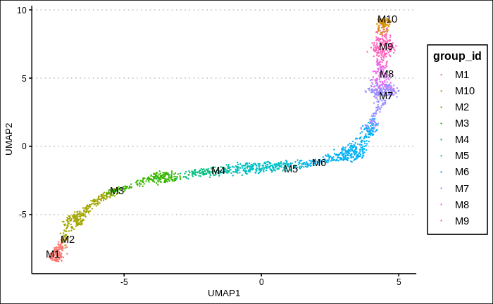

graph <- data_2k_cells$graph sample.vertices <- 0.1 meta.df <- data_2k_cells$meta.df model <- data_2k_cells$model X_pca <- data_2k_cells$X_pca

random.vertices <- sample(V(graph), size=floor(sample.vertices*length(V(graph)))) vertex.knn <- BiocNeighbors::findKNN(X=X_pca, k=21, subset=as.vector(random.vertices)) refined.vertices <- V(graph)[sapply(1:nrow(vertex.knn$index), function(i) refine_vertex(vertex.knn, i, X_pca))]

vertex.list <- sapply(1:length(random.vertices), FUN=function(X) neighbors(graph, v=random.vertices[X])) vertex.list.refined <- sapply(1:length(refined.vertices), FUN=function(X) neighbors(graph, v=refined.vertices[X]))

count.matrix.random <- countCells(graph, meta.df, vertex.list = vertex.list, random.vertices = random.vertices, sample.column = ) count.matrix.refined <- countCells(graph, meta.df, vertex.list = vertex.list.refined, random.vertices = refined.vertices, sample.column = )

spFDR.random <- testQLF(graph, count.matrix.random, model) spFDR.refined <- testQLF(graph, count.matrix.refined, model)

`r`r fdr.df.random <- data.frame(Vertex=as.integer(rownames(spFDR.random$res)), p=spFDR.random$res$PValue, adjp=spFDR.random$spFDR, adjp_fdr=spFDR.random$res$FDR, logFC=spFDR.random$res$logFC, Sig=spFDR.random$res$Sig) fdr.df.refined <- data.frame(Vertex=as.integer(rownames(spFDR.refined$res)), p=spFDR.refined$res$PValue, adjp=spFDR.refined$spFDR, logFC=spFDR.refined$res$logFC, adjp_fdr=spFDR.refined$res$FDR, Sig=spFDR.refined$res$Sig)

meta.df %>% left_join(fdr.df.random) %>% # dplyr::arrange(sampled) %>% ggplot(aes(UMAP1, UMAP2, # color= - log10(adjp), # color= - log10(p), color = logFC )) + geom_point(size=0.5) + geom_point(data=. %>% dplyr::filter(!is.na(adjp))) + theme_clean() + scale_color_gradient2(midpoint = 0, high = , low=,na.value =80) + ggtitle(sampling)

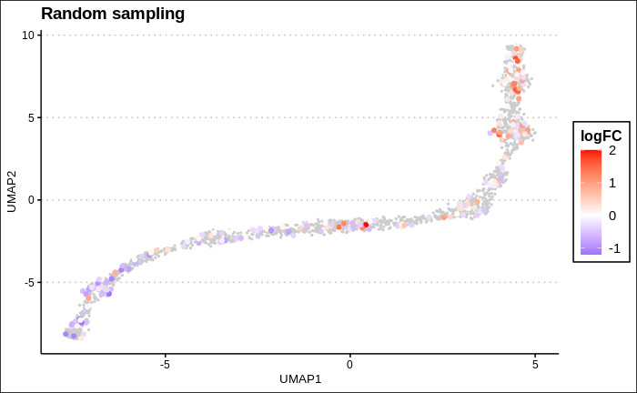

meta.df %>% left_join(fdr.df.refined) %>% # dplyr::arrange(sampled) %>% ggplot(aes(UMAP1, UMAP2, # color= - log10(adjp), # color= - log10(p), color = logFC )) + geom_point(size=0.5) + geom_point(data=. %>% dplyr::filter(!is.na(adjp))) + theme_clean() + scale_color_gradient2(midpoint = 0, high = , low=,na.value =80) + ggtitle(sampling)

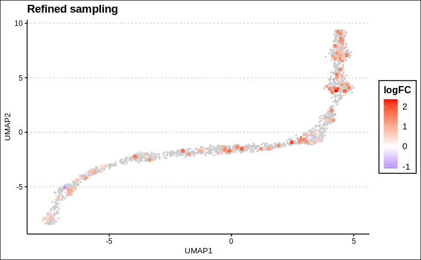

`r`r meta.df %>% left_join(fdr.df.refined) %>% dplyr::filter(!is.na(logFC)) %>% ggplot(aes(logFC, -log10(adjp), shape=Sig, color=group_id)) + geom_point() + ggtitle(sampling) + meta.df %>% left_join(fdr.df.random) %>% dplyr::filter(!is.na(logFC)) %>% ggplot(aes(logFC, -log10(adjp), shape=Sig, color=group_id)) + geom_point() + ggtitle(sampling)

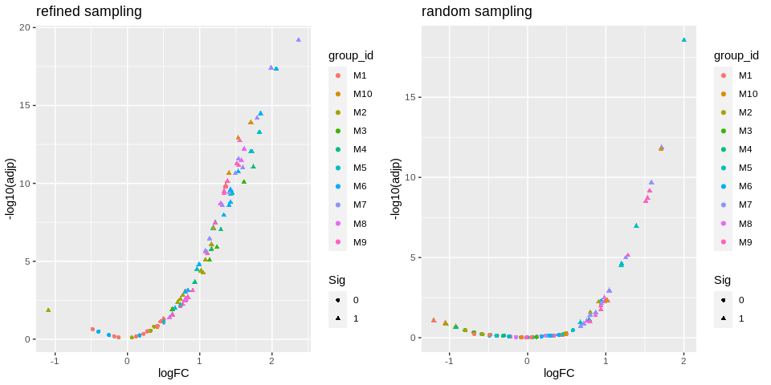

`r`r num_milestones=10

meta.df %>% ungroup() %>% left_join(fdr.df.refined) %>% dplyr::mutate(group_id = factor(group_id, levels=paste0(‘M’, 1:num_milestones))) %>% dplyr::filter(!is.na(logFC)) %>% ggplot(aes(group_id, logFC, shape=Sig, color=group_id, size= -log10(adjp))) + geom_jitter() + ggtitle(sampling) + meta.df %>% ungroup() %>% left_join(fdr.df.random) %>% dplyr::mutate(group_id = factor(group_id, levels=paste0(‘M’, 1:num_milestones))) %>% dplyr::filter(!is.na(logFC)) %>% ggplot(aes(group_id, logFC, shape=Sig, color=group_id, size= -log10(adjp))) + geom_jitter() + ggtitle(sampling)

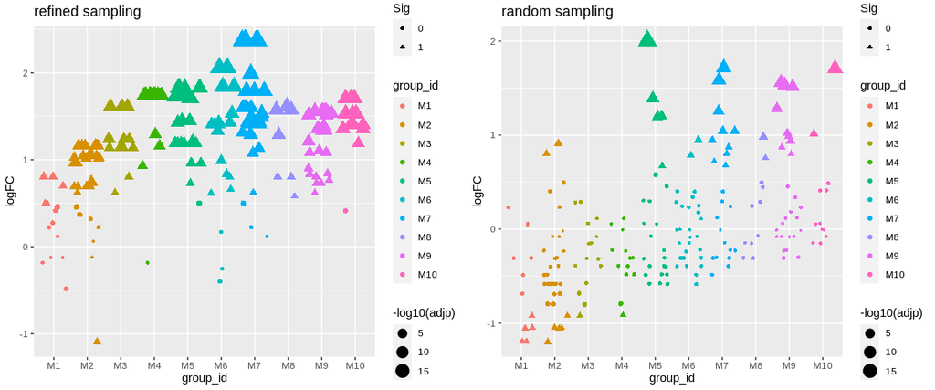

## How many neighborhoods disappear w refinement?

`r`r simulate_linear_traj <- function(num_cells, num_milestones, num_features=1000, k_param=21, seed=42, prob_start=0.1, prob_end=0.9){ set.seed(seed) ## Generate simulated dataset of trajectory dataset <- generate_dataset( model = model_linear(num_milestones = num_milestones), num_cells = num_cells, num_features = num_features ) sim2.gex <- as.matrix(dataset$expression) sim2.branches <- dataset$prior_information$groups_id sim2.time = dataset$prior_information$timecourse_continuous

## Build graph sim2.pca <- prcomp_irlba(sim2.gex, n=50, scale.=TRUE, center=TRUE) X_pca = sim2.pca$x[, c(1:30)] sim2.knn <- buildKNNGraph(x=X_pca, k=k_param, d=NA, transposed=TRUE) ## Run UMAP stem.ta.umap <- umap(sim2.pca$x[, c(1:30)], n_components=2, n_neighbors=k_param, metric=‘euclidean’, init=‘random’, min_dist=0.1) dyn.df <- data.frame(UMAP1=stem.ta.umap$layout[,1], UMAP2=stem.ta.umap$layout[,2], cell_id=rownames(sim2.gex), time=sim2.time) dyn.df <- dyn.df %>% left_join(sim2.branches)

## Simulate conditions n_groups <- length(unique(dyn.df$group_id)) p_vec <- seq(prob_start, prob_end, length.out = n_groups) a.cells <- c() for (i in 1:n_groups) { g <- paste0(\M\,i) p <- p_vec[i] m.A <- sample(dyn.df$cell_id[dyn.df$group_id==g], size=floor(sum(dyn.df$group_id==g)*p)) a.cells <- c(a.cells, m.A) }

dyn.df <- dyn.df %>% dplyr::mutate(condition = ifelse(cell_id %in% a.cells, , ‘B’))

## Simulate replicates dyn.df <- dyn.df %>% group_by(group_id) %>% dplyr::mutate(replicate=c(rep(1, floor(n()*0.3)), rep(2, floor(n()*0.3)), rep(3, n() - 2*(floor(n()*0.3)))) )

## Add sample name (condition + replicate) dyn.df$sample <- paste(dyn.df$condition, dyn.df$replicate, sep=\_\) ## Add vertex id (for counts) dyn.df$Vertex <- as.vector(V(sim2.knn))

return(list(graph=sim2.knn, X_pca=X_pca, meta.df=dyn.df, model=sim2.model))

}

[figure not shown]

`r`r data.frame(random=as.numeric(random.vertices), refined=as.numeric(refined.vertices)) %>% rowid_to_column() %>% group_by(as.factor(refined)) %>% dplyr::mutate(n_converging = n()) %>% ggplot(aes(as.factor(n_converging))) + geom_histogram(stat=)

```
Ignoring unknown parameters: binwidth, bins, pad
```

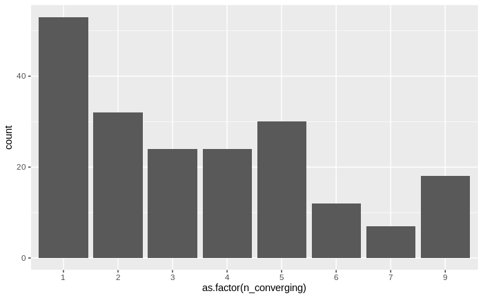

### After refinement what is the distance to the nearest sampled cell?

`r`r get_dist_to_closest_neigh <- function(graph, sample.vertices){ random.vertices <- sample(V(graph), size=floor(sample.vertices*length(V(graph)))) vertex.knn <- BiocNeighbors::findKNN(X=X_pca, k=21, subset=as.vector(random.vertices)) refined.vertices <- V(graph)[sapply(1:nrow(vertex.knn$index), function(i) refine_vertex(vertex.knn, i, X_pca))] dist_to_closest_random <- BiocNeighbors::findKNN(X=X_pca[as.vector(random.vertices),], k=1)[[]] dist_to_closest_refined <- BiocNeighbors::findKNN(X=X_pca[unique(as.vector(refined.vertices)),], k=1)[[]] dist_df <- bind_rows(data.frame(distance_to_closest=dist_to_closest_refined, sampling_scheme=‘refined’), data.frame(distance_to_closest=dist_to_closest_random, sampling_scheme=‘random’)) %>% dplyr::mutate(sample_perc=sample.vertices) }

dist_ls <- map(seq(0.1,0.6, by = 0.05), ~ get_dist_to_closest_neigh(graph, .x))

[output not shown]

## What is the relationship between neighborhood size and k?

`r`r data_5k_cells <- simulate_linear_traj(num_cells = 5000, num_milestones = 10)

```
|=========================================================================================== |100% ~0 s remaining
tied distances detected in nearest-neighbor calculationJoining, by = \cell_id\
Column `cell_id` joining factor and character vector, coercing into character vector
```

`r`r meta.df <- data_5k_cells$meta.df model <- data_5k_cells$model X_pca <- data_5k_cells$X_pca

k_vec <- seq(10,50, by=5) graph_ls <- map(k_vec, ~ buildKNNGraph(x=X_pca, k=.x, d=NA, transposed=TRUE))

[figure not shown]

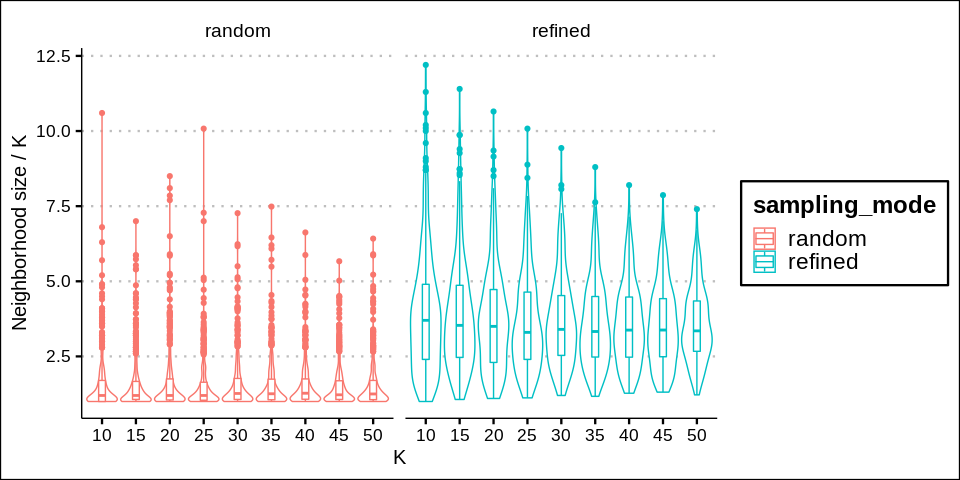

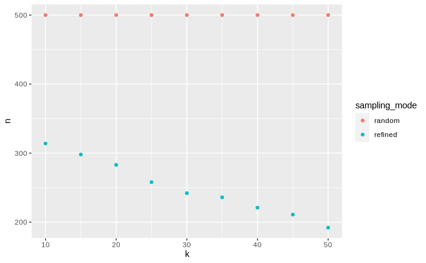